# 三维散点图

庄闪闪

2020-11-23

上期我们说了气泡图。如果我们将气泡图的三维数据绘制到三维坐标系中，通常称其为**三维散点图**，即用在三维X-Y-Z图上针对一个或多个数据序列绘出三个度量的一种图表。

有关散点图前几部分系列可见（可跳转）：

- 趋势显示的二维散点图
- 分布显示的二维散点图
- 气泡图

R 中`scatterplot3d`包的`scatterplot3d()`函数、`rgl`包的[plot3d()](http://www.rforscience.com/rpackages/visualisation/oceanview/)函数、`plot3D`包的`scatter3D()`函数等都可以绘制三维散点图。

下面将从两个包（`scatter3D()`,`plot3d()`）入手，一步步带你完成三维散点图的绘制。本文内容丰富，希望大家都能学到自己想要的内容，学习不易，欢迎反馈建议。

```r
library(plot3D)
library(scales)
library(RColorBrewer)
```

## 数据介绍

```r
df<-read.csv("ThreeD_Scatter_Data.csv",header=T)
head(df)
```

```
##   mph Gas_Mileage Power Weight Engine_Displacement
## 1  23          19    69    821              3687.7
## 2  13          17    80   1287              4261.4
## 3  13          22    55   1535              1983.2
## 4  22          34    55   1037              1770.1
## 5  14          29    55   1082              1589.8
## 6  19          26    49   1285              1294.8
```

```r
knitr::kable(head(iris))
```

| Sepal.Length | Sepal.Width | Petal.Length | Petal.Width | Species |
| --- | --- | --- | --- | --- |
| 5.1 | 3.5 | 1.4 | 0.2 | setosa |
| 4.9 | 3.0 | 1.4 | 0.2 | setosa |
| 4.7 | 3.2 | 1.3 | 0.2 | setosa |
| 4.6 | 3.1 | 1.5 | 0.2 | setosa |
| 5.0 | 3.6 | 1.4 | 0.2 | setosa |
| 5.4 | 3.9 | 1.7 | 0.4 | setosa |

## plot3D包scatter3D()

```
scatter3D (x, y, z, ..., colvar = z, phi = 40, theta = 40,
           col = NULL, NAcol = "white", breaks = NULL,
           colkey = NULL, panel.first = NULL,
           clim = NULL, clab = NULL,
           bty = "b", CI = NULL, surf = NULL,
           add = FALSE, plot = TRUE)
```

```r
# pmar <- par(mar = c(5.1, 4.1, 4.1, 6.1))
with(iris, scatter3D(x = Sepal.Length, y = Sepal.Width, z = Petal.Length,
  pch = 21, cex = 1.5,col="black",bg="#F57446",
                   xlab = "Sepal.Length",
                   ylab = "Sepal.Width",
                   zlab = "Petal.Length",
                   # zlim=c(40,180),
                   ticktype = "detailed",bty = "f",box = TRUE,
                   #panel.first = panelfirst,
                   theta = 60, phi = 20, d=3,
                   colkey = FALSE)#list(length = 0.5, width = 0.5, cex.clab = 0.75))
)
```

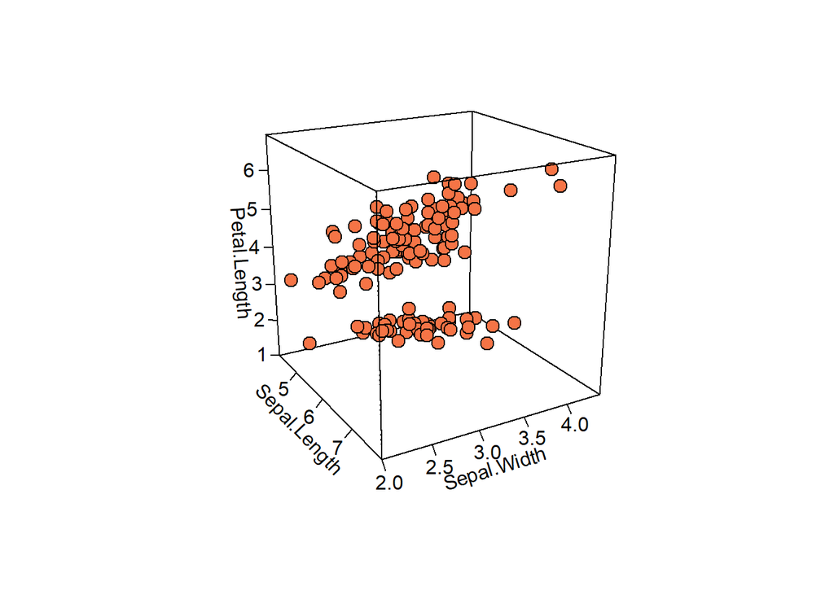

我们先自己构造一个颜色映射的颜色条RdYlGn，再绘制三维散点图，然后根据映射的数值添加图例颜色条。

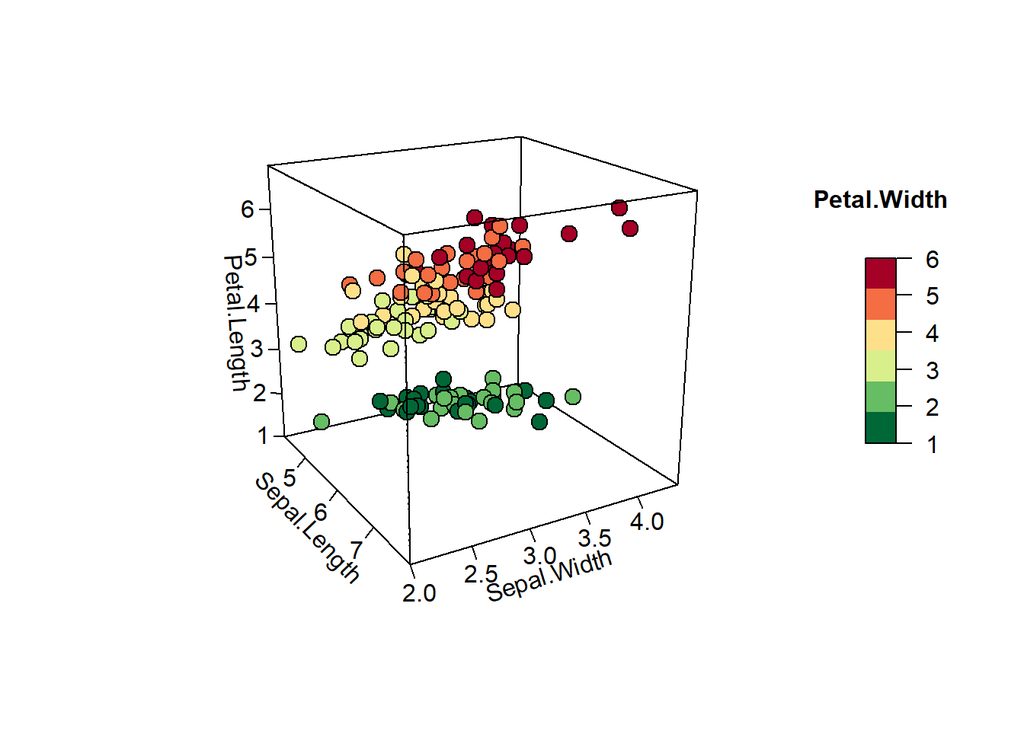

```r
library(tidyverse)
iris = iris %>% mutate(quan = ntile(Petal.Width,6))
colormap <- colorRampPalette(rev(brewer.pal(11,'RdYlGn')))(6)#legend颜色配置
pmar <- par(mar = c(5.1, 4.1, 4.1, 6.1))
# 绘图
with(iris, scatter3D(x = Sepal.Length, y = Sepal.Width, z = Petal.Length,pch = 21, cex = 1.5,col="black",bg=colormap[iris$quan],
     xlab = "Sepal.Length",
     ylab = "Sepal.Width",
     zlab = "Petal.Length",
     ticktype = "detailed",bty = "f",box = TRUE,
     theta = 60, phi = 20, d=3,
     colkey = FALSE)
)
colkey (col=colormap,clim=range(iris$quan),clab = "Petal.Width", add=TRUE, length=0.4,side = 4)
```

第2种方法就是将第四维数据映射到数据点的大小上，即三维气泡图

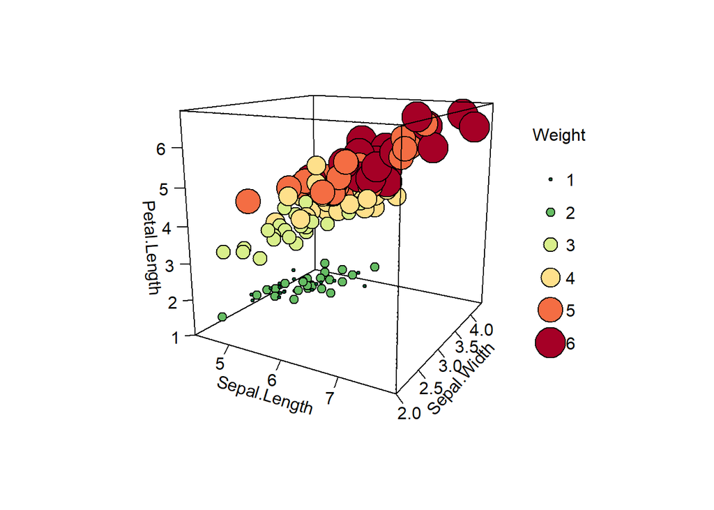

```r
pmar <- par(mar = c(5.1, 4.1, 4.1, 6.1))
# 绘图
with(iris, scatter3D(x = Sepal.Length, y = Sepal.Width, z = Petal.Length,pch = 21,
                     cex = rescale(iris$quan, c(.5, 4)),col="black",bg=colormap[iris$quan],
                     xlab = "Sepal.Length",
                     ylab = "Sepal.Width",
                     zlab = "Petal.Length",
                     ticktype = "detailed",bty = "f",box = TRUE,
                     theta = 30, phi = 15, d=2,
                     colkey = FALSE)
)
breaks =1:6
legend("right",title =  "Weight",legend=breaks,pch=21,
       pt.cex=rescale(breaks, c(.5, 4)),y.intersp=1.6,
       pt.bg = colormap[1:6],bg="white",bty="n")
```

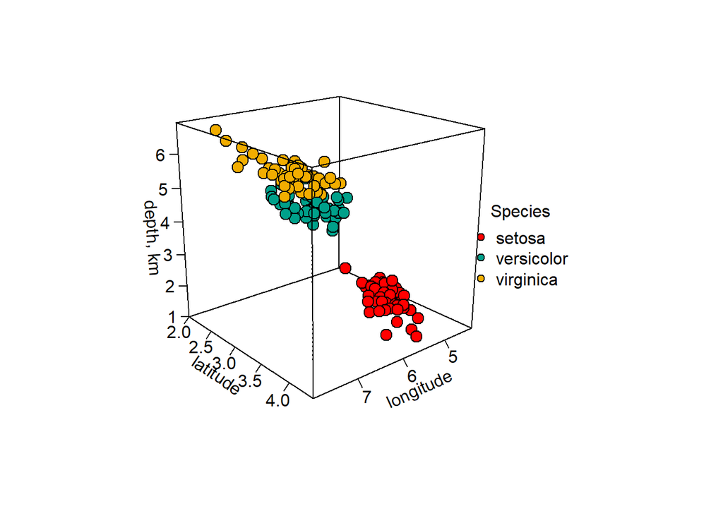

```r
library(wesanderson)
pmar <- par(mar = c(5.1, 4.1, 4.1, 7.1))
colors0 <-  wes_palette(n=3, name="Darjeeling1")
colors <- colors0[as.numeric(iris$Species)]
with(iris, scatter3D(x = Sepal.Length, y = Sepal.Width, z = Petal.Length, #bgvar = mag,
                   pch = 21, cex = 1.5,col="black",bg=colors,
                   xlab = "longitude", ylab = "latitude",
                   zlab = "depth, km",
                   ticktype = "detailed",bty = "f",box = TRUE,
                   #panel.first = panelfirst,
                   theta = 140, phi = 20, d=3,
                   colkey = FALSE)#list(length = 0.5, width = 0.5, cex.clab = 0.75))
)

legend("right",title =  "Species",legend=c("setosa", "versicolor", "virginica"),pch=21,
       cex=1,y.intersp=1,pt.bg = colors0,bg="white",bty="n")
```

## rgl包 plot3d()

[rgl包](https://www.rdocumentation.org/packages/rgl/versions/0.100.54)是在r中构建3d图表的最佳选择，请参阅这篇介绍3d散点图使用它的文章。

```
plot3d(x, y, z,
    xlab, ylab, zlab, type = "p", col,
    size, lwd, radius,
    add = FALSE, aspect = !add,
    xlim = NULL, ylim = NULL, zlim = NULL,
    forceClipregion = FALSE, ...)
```

```r
# library
library(rgl)

# Add a new column with color
mycolors <- c('royalblue1', 'darkcyan', 'oldlace')
iris$color <- mycolors[ as.numeric(iris$Species) ]

# Plot
plot3d(
  x=iris$`Sepal.Length`, y=iris$`Sepal.Width`, z=iris$`Petal.Length`,
  col = iris$color,
  type = 's',
  radius = .1,
  xlab="Sepal Length", ylab="Sepal Width", zlab="Petal Length")

# writeWebGL( filename="HtmlWidget/3dscatter.html" ,  width=600, height=600)
```

[output not shown]

## 动态3D图

[Animated 3d chart with R.](https://www.r-graph-gallery.com/3-r-animated-cube.html)

```r
library(rgl)
library(magick)
```

```r
# This is ugly
colors <- c("royalblue1", "darkcyan", "oldlace")
iris$color <- colors[ as.numeric( as.factor(iris$Species) ) ]

# Static chart
# plot3d( iris[,1], iris[,2], iris[,3], col = iris$color, type = "s", radius = .2 )

# We can indicate the axis and the rotation velocity
# play3d( spin3d( axis = c(0, 0, 1), rpm = 20), duration = 50 )

# Save like gif
# movie3d(
#   movie="3dAnimatedScatterplot",
#   spin3d( axis = c(0, 0, 1), rpm = 7),
#   duration = 10,
#   dir = "~/Desktop",
#   type = "gif",
#   clean = TRUE
# )
```